# Stack Overflow General Analysis

RNinjas

04 12 2021

## General Information About Data

*stackover_full* includes the last 5 years stack overflow survey results. This data consist of 342 variable and 387030 observations.

When the number of participants by years is examined

```r
stackover_full%>%group_by(Year)%>%count()
```

```
## # A tibble: 5 x 2
## # Groups:   Year [5]
##    Year     n
##   <int> <int>
## 1  2017 51392
## 2  2018 98855
## 3  2019 88883
## 4  2020 64461
## 5  2021 83439
```

### Participant’s Country Analysis

The survey participants have different countries.

That there are looking at the unique value of countries, same country name spelled differently such as “United States” vs “United States of America”. This type of data should be converted.

```r
head(unique(stackover_full$Country),20)
```

```
##  [1] "United States"  "United Kingdom" "Switzerland"    "New Zealand"
##  [5] "Poland"         "Colombia"       "France"         "Canada"
##  [9] "Germany"        "Greece"         "Brazil"         "Israel"
## [13] "Italy"          "Belgium"        "India"          "Chile"
## [17] "Croatia"        "Argentina"      "Netherlands"    "Denmark"
```

```r
stackover_full=stackover_full%>%
  mutate(Country=case_when(Country=="United States of America" ~ "United States",
                           Country=="United Kingdom of Great Britain and Northern Ireland" ~"United Kingdom",
                           Country=="Viet Nam" ~"Vietnam",
                           Country=="Iran, Islamic Republic of..." ~"Iran",
                           Country=="Congo, Republic of the..." ~"Democratic Republic of the Congo",
                           Country=="Venezuela, Bolivarian Republic of..." ~"Venezuela",
                           Country=="Dominican Republic" ~"Dominica",
                           Country=="The former Yugoslav Republic of Macedonia" ~"Macedonia",
                           Country=="Libyan Arab Jamahiriya" ~"Libya",
                           Country=="Slovak Republic" ~"Slovakia",
                           Country=="Azerbaidjan" ~"Azerbaijan",
                           Country=="Tadjikistan" ~"Tajikistan",
                           Country=="Syrian Arab Republic" ~"Syria",
                           Country=="Democratic People's Republic of Korea" ~"North Korea",
                           Country=="Republic of Korea" ~"South Korea",
                           Country=="United Republic of Tanzania" ~"Tanzania",
                           Country=="Hong Kong (S.A.R.)" ~"Hong Kong",
                           Country=="" ~"Not Responding",
                           Country=="I prefer not to say" ~"Not Responding",
                           TRUE ~Country))
```

After data cleaning according to Country,

Let see the distirbution participants.

```r
countrydist=stackover_full%>%
  group_by(Country) %>%
  count()%>%
  arrange(desc(Country))

countrydist
```

```
## # A tibble: 233 x 2
## # Groups:   Country [233]
##    Country                      n
##    <chr>                    <int>
##  1 Zimbabwe                   165
##  2 Zambia                      74
##  3 Zaire                        2
##  4 Yemen                       62
##  5 Virgin Islands (USA)         5
##  6 Virgin Islands (British)     2
##  7 Vietnam                   1433
##  8 Venezuela                  444
##  9 Vatican City State           1
## 10 Uzbekistan                 232
## # ... with 223 more rows
```

Some country participant count is very low, so these data’s are eliminated.

Countries with a below-average number of participants were excluded from the analysis.

Most of the participants are from United States, India, Germany, United Kingdom and Canada.

```r
countrydist_elimination=countrydist %>%
  mutate(avg=mean(countrydist$n)) %>%
  filter(n>avg) %>%
  select(Country,n)%>%
  arrange(desc(n))

countrydist_elimination
```

```
## # A tibble: 44 x 2
## # Groups:   Country [44]
##    Country                n
##    <chr>              <int>
##  1 United States      80470
##  2 India              46893
##  3 Germany            25983
##  4 United Kingdom     24724
##  5 Canada             14224
##  6 France             11309
##  7 Brazil              9302
##  8 Poland              8417
##  9 Russian Federation  8002
## 10 Australia           7688
## # ... with 34 more rows
```

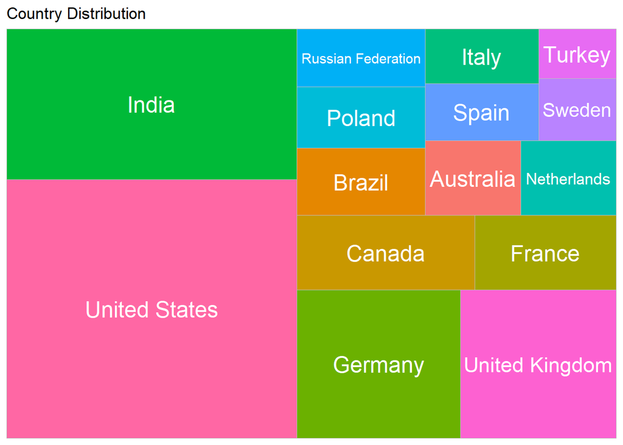

```r
countrydist_graph=countrydist %>%
  mutate(avg=mean(countrydist$n)) %>%
  filter(n>avg) %>%
  select(Country,n)%>%
  arrange(desc(n)) %>%
  head(15)


ggplot(countrydist_graph,
       aes(fill = Country,
           area = n,
           label = Country)) +
  geom_treemap() +
  geom_treemap_text(colour = "white",
                    place = "centre") +
  labs(title = "Country Distribution") +
  theme(legend.position = "none")
```

### Participant’s Branch Analysis

The survey participants have different branches. That there are looking at the unique value of branches:

```r
unique(stackover_full$MainBranch)
```

```
##  [1] "Student"
##  [2] "Professional developer"
##  [3] "Professional non-developer who sometimes writes code"
##  [4] "Used to be a professional developer"
##  [5] "None of these"
##  [6] ""
##  [7] "I am a student who is learning to code"
##  [8] "I am not primarily a developer, but I write code sometimes as part of my work"
##  [9] "I am a developer by profession"
## [10] "I code primarily as a hobby"
## [11] "I used to be a developer by profession, but no longer am"
```

11 different categories reduced to 5 categories by doing the following conversion.

```r
stackover_full=stackover_full%>%
  mutate(MainBranch=case_when(MainBranch=="I am a developer by profession" ~ "Professional developer",
                              MainBranch=="Used to be a professional developer" ~ "Professional developer",
                              MainBranch=="I used to be a developer by profession, but no longer am" ~ "Professional developer",
                              MainBranch=="I am a student who is learning to code" ~"Student",
                              MainBranch=="Professional non-developer who sometimes writes code" ~ "Hobby",
                              MainBranch=="I code primarily as a hobby" ~ "Hobby",
                              MainBranch=="I am not primarily a developer, but I write code sometimes as part of my work" ~"Sometimes Coding",
                              MainBranch=="" ~"None of these",
                              TRUE ~MainBranch))

unique(stackover_full$MainBranch)
```

```
## [1] "Student"                "Professional developer" "Hobby"
## [4] "None of these"          "Sometimes Coding"
```

Looking at the distribution of categories over all participants:

Stackoverflow is used by professional developers by %54.

```r
mainbranchdist=stackover_full%>%
  group_by(MainBranch)%>%
  count()%>%
  mutate(perc_n=round(n/NROW(stackover_full)*100,2))%>%
  arrange(desc(n))
mainbranchdist
```

```
## # A tibble: 5 x 3
## # Groups:   MainBranch [5]
##   MainBranch                  n perc_n
##   <chr>                   <int>  <dbl>
## 1 Professional developer 212143  54.8
## 2 None of these          101133  26.1
## 3 Student                 38412   9.92
## 4 Sometimes Coding        19619   5.07
## 5 Hobby                   15723   4.06
```

The branch of the participants’ distribution chart:

```r
hchart(mainbranchdist,hcaes(x=MainBranch,y=perc_n),type="column",name="Percentage",color="#80FF40") %>%
  hc_exporting(enabled = TRUE) %>%
  hc_title(text="Distrubition of Participants",align="center") %>%
  hc_add_theme(hc_theme_elementary())
```

[interactive chart not shown]

### Participant’s Age Analysis

This site is used by people from different age groups. By looking at the age distribution of the participants, it can be determined which age range is used more actively.

```r
unique(stackover_full$Age)
```

```
##  [1] ""                   "25 - 34 years old"  "35 - 44 years old"
##  [4] "18 - 24 years old"  "45 - 54 years old"  "55 - 64 years old"
##  [7] "Under 18 years old" "65 years or older"  "55 - 64 Years Old"
## [10] "25-34 years old"    "18-24 years old"    "35-44 years old"
## [13] "Prefer not to say"  "45-54 years old"    "55-64 years old"
```

Considering the age values, there is a need for regrouping.

```r
stackover_full=stackover_full%>%
  mutate(Age=gsub(" years old", "", tolower(Age))) %>%
  mutate(Age=gsub(" - ", "-", tolower(Age))) %>%
  mutate(Age=case_when(Age=="" ~"Prefer not to say",Age=="prefer not to say" ~"Prefer not to say",TRUE ~Age))

unique(stackover_full$Age)
```

```
## [1] "Prefer not to say" "25-34"             "35-44"
## [4] "18-24"             "45-54"             "55-64"
## [7] "under 18"          "65 years or older"
```

When the age distribution by years is investigated:

```r
agedist=stackover_full %>%
  group_by(Year,Age) %>%
  count() %>%
  arrange(desc(Year,Age))

agedist
```

```
## # A tibble: 33 x 3
## # Groups:   Year, Age [33]
##     Year Age                   n
##    <int> <chr>             <int>
##  1  2021 18-24             20993
##  2  2021 25-34             32568
##  3  2021 35-44             15183
##  4  2021 45-54              5472
##  5  2021 55-64              1819
##  6  2021 65 years or older   421
##  7  2021 Prefer not to say  1607
##  8  2021 under 18           5376
##  9  2020 18-24             10026
## 10  2020 25-34             22352
## # ... with 23 more rows
```

Since the participants did not specify their ages in 2017, no inference can be made for this year.

When the graph is examined, it can be said that the 24-34 age range is actively using stackoverflow.

In recent years, it has been seen that the “18-24” and “under 18” age group uses stackoverflow more. In this way, it can be said that there is a tendency towards programming in the younger generation.

```r
highchart() %>%
  hc_add_series(agedist, type = "bar", hcaes(x = Year, group = Age, y = n)) %>%
  hc_xAxis(categories = agedist$Age)
```

[interactive chart not shown]

### Participant’s Education Level Analysis

```r
unique(stackover_full$EdLevel)
```

```
##  [1] "Secondary school"
##  [2] "Some college/university study without earning a bachelor's degree"
##  [3] "Bachelor's degree"
##  [4] "Doctoral degree"
##  [5] "Master's degree"
##  [6] "Professional degree"
##  [7] "Primary/elementary school"
##  [8] "I prefer not to answer"
##  [9] "I never completed any formal education"
## [10] "Bachelor’s degree (BA, BS, B.Eng., etc.)"
## [11] "Associate degree"
## [12] "Some college/university study without earning a degree"
## [13] "Master’s degree (MA, MS, M.Eng., MBA, etc.)"
## [14] "Secondary school (e.g. American high school, German Realschule or Gymnasium, etc.)"
## [15] ""
## [16] "Professional degree (JD, MD, etc.)"
## [17] "Other doctoral degree (Ph.D, Ed.D., etc.)"
## [18] "Master’s degree (M.A., M.S., M.Eng., MBA, etc.)"
## [19] "Bachelor’s degree (B.A., B.S., B.Eng., etc.)"
## [20] "Associate degree (A.A., A.S., etc.)"
## [21] "Other doctoral degree (Ph.D., Ed.D., etc.)"
## [22] "Something else"
```

This data should be rearrange .

```r
stackover_full$EdLevel=gsub("\\([^)]*)", "",stackover_full$EdLevel)
stackover_full$EdLevel=gsub("degree ","degree",stackover_full$EdLevel)
stackover_full$EdLevel=gsub("’","'",stackover_full$EdLevel)
stackover_full$EdLevel=gsub("without earning a bachelor's degree","without earning a degree",stackover_full$EdLevel)
stackover_full$EdLevel=gsub("school ","school",stackover_full$EdLevel)
unique(stackover_full$EdLevel)
```

```
##  [1] "Secondary school"
##  [2] "Some college/university study without earning a degree"
##  [3] "Bachelor's degree"
##  [4] "Doctoral degree"
##  [5] "Master's degree"
##  [6] "Professional degree"
##  [7] "Primary/elementary school"
##  [8] "I prefer not to answer"
##  [9] "I never completed any formal education"
## [10] "Associate degree"
## [11] ""
## [12] "Other doctoral degree"
## [13] "Something else"
```

These values were re-categorized according to the level of education.

```r
stackover_full=stackover_full %>%
  mutate(EdLevel_Bucket=case_when(EdLevel %in% c("Secondary school","Primary/elementary school","Something else")~1,
                                  EdLevel %in% c("Associate degre","Bachelor's degree")~2,
                                  EdLevel %in% c("Doctoral degree","Master's degree","Other doctoral degree","Professional degree")~3,
                                  EdLevel %in% c("I never completed any formal education","Some college/university study without earning a degree")~4,
                                  EdLevel %in% c("I prefer not to answer","")~5,
                                  TRUE ~6))


edleveldist=stackover_full%>%group_by(Year,EdLevel_Bucket)%>%count()
```

```r
highchart() %>%
  hc_add_series(edleveldist, type = "bar", hcaes(x = Year, group = EdLevel_Bucket, y = n)) %>%
  hc_xAxis(categories = edleveldist$EdLevel_Bucket)
```

[interactive chart not shown]